# Practical Machine Learning Project

Patricio Del Boca

22/11/2015

## Project Summary

Using devices such as *Jawbone Up*, *Nike FuelBand*, and *Fitbit* it is now possible to collect a large amount of data about personal activity relatively inexpensively. One thing that people regularly do is quantify how much of a particular activity they do, but they rarely quantify how well they do it. In this project, your goal will be to use data from accelerometers on the belt, forearm, arm, and dumbell of 6 participants. They were asked to perform barbell lifts correctly and incorrectly in 5 different ways.

**The goal of this project is to predict the manner in which they did the exercise. This is the “classe” variable in the training set.**

```r
library(ggplot2)
library(caret)
library(reshape2)
library(doMC)
set.seed(31415) # Reproducible Research
setwd("~/Repos/datasciencecoursera/practical-machine-learning/project")
```

## Get Data

To be fully reproducible, I’ve included code to donwload the data.

```r
trainUrl <-"https://d396qusza40orc.cloudfront.net/predmachlearn/pml-training.csv"
testUrl <- "https://d396qusza40orc.cloudfront.net/predmachlearn/pml-testing.csv"
trainFile <- "./data/pml-training.csv"
testFile  <- "./data/pml-testing.csv"
if (!file.exists("./data")) {
    dir.create("./data")
}
if (!file.exists(trainFile)) {
    download.file(trainUrl, destfile=trainFile, method="curl")
}
if (!file.exists(testFile)) {
    download.file(testUrl, destfile=testFile, method="curl")
}
trainingRaw <- read.csv('./data//pml-training.csv')
testingRaw <- read.csv('./data//pml-testing.csv')
```

## Clean Data

Since both files has the same structure, Ive created a function to clean the data and keep the code DRY.

```r
cleanData <- function(dataset){
    dataset <- dataset[, colSums(is.na(dataset)) == 0]
    dataset <- dataset[, !grepl("timestamp", colnames(dataset))]
    dataset <- dataset[, !grepl("X", colnames(dataset))]
    dataset <- dataset[, !grepl("window", colnames(dataset))]
    dataset <- dataset[, !grepl("user_name", colnames(dataset))]
    classe <- dataset$classe
    dataset <- dataset[,sapply(dataset, is.numeric)]
    dataset$classe <- classe
    dataset
}

training <- cleanData(trainingRaw)
sum(!complete.cases(training)) # Check if all rows are completed
```

```
## [1] 0
```

```r
testing <- cleanData(testingRaw)
sum(!complete.cases(testing)) # Check if all rows are completed
```

```
## [1] 0
```

## Train Model

I will use Random Forest since it is a straight forward method to tackle classification problems.

#### Split Data:

Split the train data to evaluate the performance.

```r
indexTrain <- createDataPartition(training$classe, p=0.7, list=FALSE)
trainData <- training[indexTrain,]
testingData <- training[-indexTrain,]
```

#### Parameters:

- CV: To avoid overfitting I will use a cross validation method with k = 7.
- Allow Parallel: To get the most of my cores and train faster.
- Number of Trees: 250 it’s a good boiler plate number for training RF.

```r
registerDoMC(cores = detectCores() - 1) # This will use all of the cores but one

## All subsequent models are then run in parallel
trControl <- trainControl(method="cv", 7)
fit <- train(classe ~ ., method="rf", trControl=trControl,
             data=trainData, allowParallel=TRUE, ntree=250)
fit$results
```

```
##   mtry  Accuracy     Kappa  AccuracySD     KappaSD
## 1    2 0.9922105 0.9901460 0.002595270 0.003283474
## 2   27 0.9914828 0.9892261 0.002366336 0.002993459
## 3   52 0.9876974 0.9844368 0.001893356 0.002395867
```

```r
fit$finalModel
```

```
##
## Call:
##  randomForest(x = x, y = y, ntree = 250, mtry = param$mtry, allowParallel = TRUE)
##                Type of random forest: classification
##                      Number of trees: 250
## No. of variables tried at each split: 2
##
##         OOB estimate of  error rate: 0.68%
## Confusion matrix:
##      A    B    C    D    E class.error
## A 3900    4    0    1    1 0.001536098
## B   12 2639    7    0    0 0.007148232
## C    0   19 2375    2    0 0.008764608
## D    0    0   34 2215    3 0.016429840
## E    0    0    4    6 2515 0.003960396
```

General Performance:

- Accuracy: **99.22%**
- OOB Estimate of Error Rate: **0.68%**
- No. of variables tried at each split: **2**

## Prediction on Testing Data

Now we test out model in the Testing Data:

```r
pred <- predict(fit, testingData)
confusionMatrix(testingData$classe, pred)
```

```
## Confusion Matrix and Statistics
##
##           Reference
## Prediction    A    B    C    D    E
##          A 1673    1    0    0    0
##          B    3 1132    4    0    0
##          C    0    2 1023    1    0
##          D    0    0   19  945    0
##          E    0    0    0    1 1081
##
## Overall Statistics
##
##                Accuracy : 0.9947
##                  95% CI : (0.9925, 0.9964)
##     No Information Rate : 0.2848
##     P-Value [Acc > NIR] : < 2.2e-16
##
##                   Kappa : 0.9933
##  Mcnemar's Test P-Value : NA
##
## Statistics by Class:
##
##                      Class: A Class: B Class: C Class: D Class: E
## Sensitivity            0.9982   0.9974   0.9780   0.9979   1.0000
## Specificity            0.9998   0.9985   0.9994   0.9962   0.9998
## Pos Pred Value         0.9994   0.9939   0.9971   0.9803   0.9991
## Neg Pred Value         0.9993   0.9994   0.9953   0.9996   1.0000
## Prevalence             0.2848   0.1929   0.1777   0.1609   0.1837
## Detection Rate         0.2843   0.1924   0.1738   0.1606   0.1837
## Detection Prevalence   0.2845   0.1935   0.1743   0.1638   0.1839
## Balanced Accuracy      0.9990   0.9979   0.9887   0.9970   0.9999
```

```r
oos <- (1 - confusionMatrix(testingData$classe, pred)$overall[1]) * 100
```

It seems that there isn’t a clear pattern on the Errors of the predictor (See Apendix), so we conclude our modeling phase.

## Prediction on New Data:

This will predict the data to submit in the exercise

```r
predNewData <- predict(fit, testing[,-which(names(testing) %in% c("problem_id"))])
predNewData
```

```
##  [1] B A B A A E D B A A B C B A E E A B B B
## Levels: A B C D E
```

```r
if (!file.exists("./predictions")) {
    dir.create("./predictions")
}
pml_write_files = function(x){
  n = length(x)
  for(i in 1:n){
    filename = paste0("./predictions/problem_id_",i,".txt")
    write.table(x[i],file=filename,quote=FALSE,row.names=FALSE,col.names=FALSE)
  }
}
pml_write_files(predNewData)
```

## Conclusion

Random Forest is one of the state-of-the-art Machine Learning algorithms. Without furter pre-processing it was able to predict with high accuracy and relatively low OOSE. This demonstrate the prediction power of the algorithms and the amount of applications they have to solve all kind of problems.

## Apendix

#### Principal Component Analysis

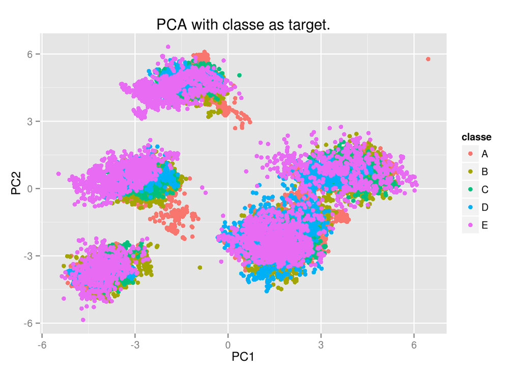

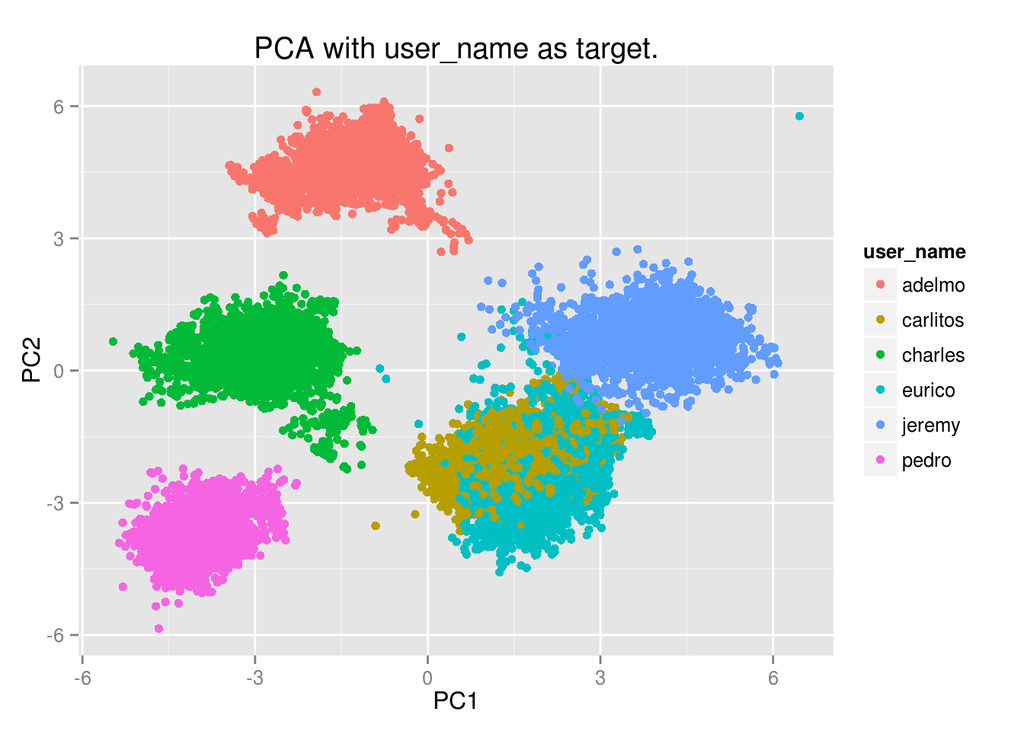

#### Highly correlated variables

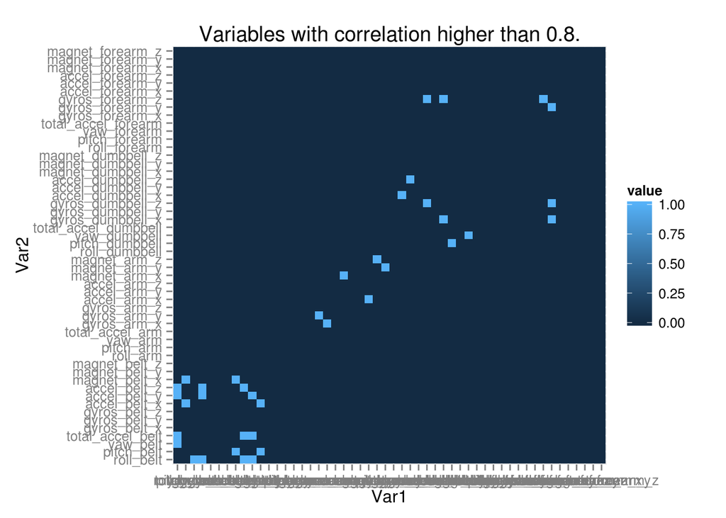

```r
M <- abs(cor(training[,-53]))
diag(M) <- 0
M <- ifelse(M>0.8, 1, 0)
qplot(x=Var1, y=Var2, data=melt(M), fill=value, geom="tile") +
  ggtitle("Variables with correlation higher than 0.8.")
```

#### Random Forest

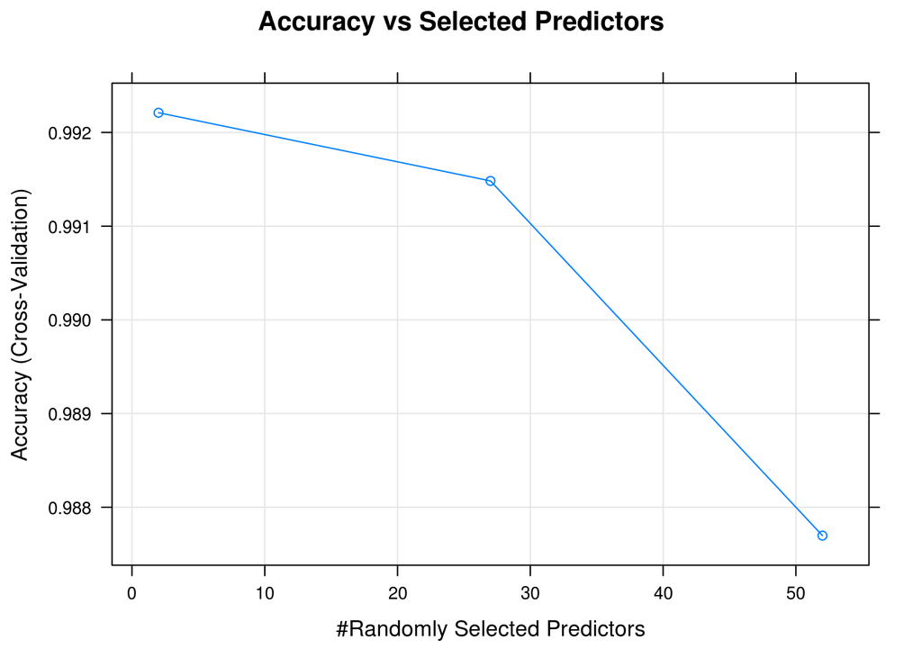

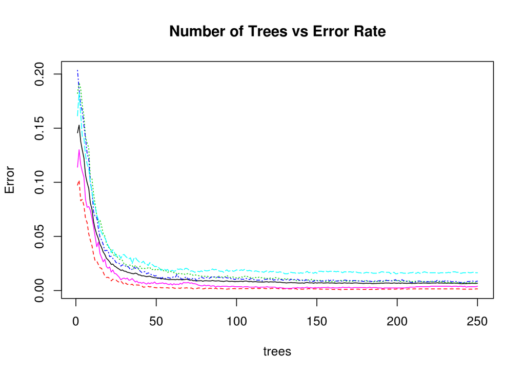

#### Prediction Errors:

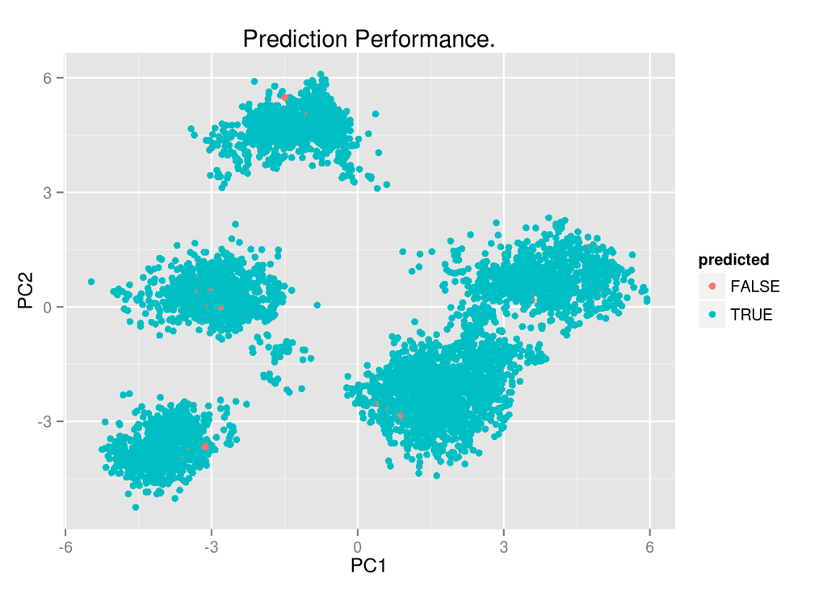